# Progress report 1

Metadata profiling

Updated: 2019-05-15 11:55:57

## Preamble

- Load Metadata
  - Inspect the metadata column names.
  - Remove number sign at the name of column one.
  - Note that Var1 starts at index 7.
  - Select important variables for downstream analysis.
  - Define each categoric variable as factor.

```r
# Load samplemetadata
samplemetadata <- readr::read_table2(file="~/OneDrive/CaseStudy/iMAPpipeline_rev2/iMAPdemo/iMAP/resources/metadata/samplemetadata.tsv", col_names = T)
colnames(samplemetadata)[1] <- "SampleID"

# View column names
names(samplemetadata)
```

```
 [1] "SampleID"              "BarcodeSequence"
 [3] "ForwardPrimerSequence" "ReversePrimerSequence"
 [5] "ForwardRead"           "ReverseRead"
 [7] "Var1"                  "Var2"
 [9] "Var3"                  "Var4"
[11] "Description"
```

```r
# Define categoric variables like
samplemetadata$SampleID <- as.factor(samplemetadata$SampleID)
samplemetadata$Var1 <- as.factor(samplemetadata$Var1)
samplemetadata$Var2 <- as.factor(samplemetadata$Var2)
samplemetadata$Var3 <- as.factor(samplemetadata$Var3)
samplemetadata$Var4 <- as.factor(samplemetadata$Var4)

# Add more variables as needed
```

### Status of sample metadata

```r
library(dplyr)
library(knitr)

# show data
metadatastatus %>% knitr::kable()
```

| variable | q_zeros | p_zeros | q_na | p_na | q_inf | p_inf | type | unique |
| --- | --- | --- | --- | --- | --- | --- | --- | --- |
| SampleID | 0 | 0 | 0 | 0 | 0 | 0 | factor | 8 |
| BarcodeSequence | 0 | 0 | 8 | 100 | 0 | 0 | logical | 0 |
| ForwardPrimerSequence | 0 | 0 | 8 | 100 | 0 | 0 | logical | 0 |
| ReversePrimerSequence | 0 | 0 | 8 | 100 | 0 | 0 | logical | 0 |
| ForwardRead | 0 | 0 | 0 | 0 | 0 | 0 | character | 8 |
| ReverseRead | 0 | 0 | 0 | 0 | 0 | 0 | character | 8 |
| Var1 | 0 | 0 | 0 | 0 | 0 | 0 | factor | 2 |
| Var2 | 0 | 0 | 0 | 0 | 0 | 0 | factor | 2 |
| Var3 | 0 | 0 | 0 | 0 | 0 | 0 | factor | 4 |
| Var4 | 0 | 0 | 0 | 0 | 0 | 0 | factor | 4 |
| Description | 0 | 0 | 0 | 0 | 0 | 0 | character | 1 |

Key: **q_zeros**: quantity of missing data; **p_zeros**: percentage of missing data, **q_na**: quantity of NA; **p_na**: percentage of NA, **q_inf**: quantity of infinite values; **p_inf**: percentage of infinity values, **type**: factor, character, integer or numeric; **unique**: levels of the variable.

### Selected variables for downsteam analysis

> This is important for mapping to output from dowmstream analysis

```r
library(dplyr)
library(knitr)

# show variable status
varstatus %>% knitr::kable()
```

| variable | q_zeros | p_zeros | q_na | p_na | q_inf | p_inf | type | unique |
| --- | --- | --- | --- | --- | --- | --- | --- | --- |
| SampleID | 0 | 0 | 0 | 0 | 0 | 0 | factor | 8 |
| Var1 | 0 | 0 | 0 | 0 | 0 | 0 | factor | 2 |
| Var2 | 0 | 0 | 0 | 0 | 0 | 0 | factor | 2 |
| Var3 | 0 | 0 | 0 | 0 | 0 | 0 | factor | 4 |
| Var4 | 0 | 0 | 0 | 0 | 0 | 0 | factor | 4 |

Key: **q_zeros**: quantity of missing data; **p_zeros**: percentage of missing data, **q_na**: quantity of NA; **p_na**: percentage of NA, **q_inf**: quantity of infinite values; **p_inf**: percentage of infinity values, **type**: factor, character, integer or numeric; **unique**: frequency of the values.

## View variable levels (first 5 rows)

```r
variables %>% head(5)  %>% knitr::kable()
```

| SampleID | Var1 | Var2 | Var3 | Var4 |
| --- | --- | --- | --- | --- |
| F3D001 | Female | Early | D001 | 1 |
| F3D006 | Female | Early | D006 | 6 |
| F3D142 | Female | Late | D142 | 142 |
| F3D143 | Female | Late | D143 | 143 |
| M1D001 | Male | Early | D001 | 1 |

## Frequency of experimental variables

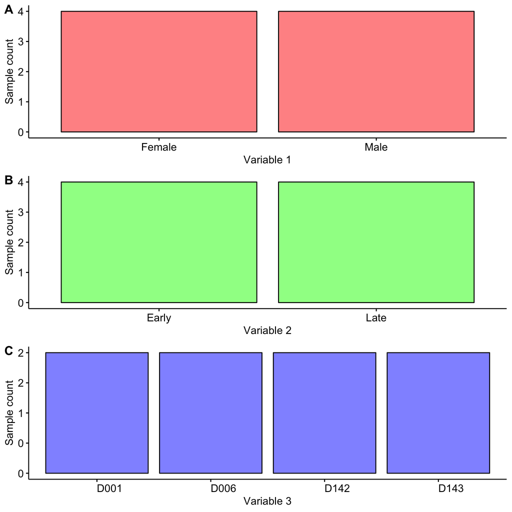

```r
library(ggplot2)

# Var1
var1histplot <- ggpubr::gghistogram(variables, x = "Var1", stat="count", fill = "#ff0000") +
  labs(x = "Variable 1", y = "Sample count")

# Var2
var2histplot <- ggpubr::gghistogram(variables, x = "Var2", stat="count", fill = "#00ff00") +
  labs(x = "Variable 2", y = "Sample count")

# Var3
var3histplot <- ggpubr::gghistogram(variables, x = "Var3", stat="count", fill = "#0000ff") +
  theme(axis.text.x=element_text(angle = 0, hjust = 0))+ scale_y_continuous(labels=scaleFUN) +
  labs(x = "Variable 3", y = "Sample count")

ggpubr::ggarrange(var1histplot,var2histplot, var3histplot, ncol = 1, nrow = 3, align = "hv", labels = c("AUTO"))
```

### Profiling metadata used in the iMAP casestudy

> Using the Casestudy metadata located in this path: iMAP/resources/metadata/samplemetadata_casestudy.tsv

```r
library("dplyr")
library("knitr")

# Load samplemetadata

samplemetadata2 <- readr::read_table2(file="~/OneDrive/CaseStudy/iMAPpipeline_rev2/iMAPdemo/iMAP/resources/metadata/samplemetadata_casestudy.tsv", col_names = T)
samplemetadata2 <- samplemetadata2[, -7]
colnames(samplemetadata2)[1] <- "SampleID"

# View column names
names(samplemetadata2)
```

```
 [1] "SampleID"              "BarcodeSequence"
 [3] "ForwardPrimerSequence" "ReversePrimerSequence"
 [5] "ForwardRead"           "ReverseRead"
 [7] "Sex"                   "Time"
 [9] "DayID"                 "DPW"
[11] "Description"
```

```r
# Define categoric variables like
samplemetadata2$SampleID <- as.factor(samplemetadata2$SampleID)
samplemetadata2$Sex <- as.factor(samplemetadata2$Sex)
samplemetadata2$Time <- as.factor(samplemetadata2$Time)
samplemetadata2$DayID <- as.factor(samplemetadata2$DayID)
samplemetadata2$DPW <- as.factor(samplemetadata2$DPW)

# Add more variables as needed

variables2 <- samplemetadata2  %>% dplyr::select("SampleID", "Sex", "Time", "DayID", "DPW" )
```

## Status of custom metadata

```r
library(dplyr)
library(knitr)

# show data
varstatus2 %>% knitr::kable()
```

| variable | q_zeros | p_zeros | q_na | p_na | q_inf | p_inf | type | unique |
| --- | --- | --- | --- | --- | --- | --- | --- | --- |
| SampleID | 0 | 0.00 | 0 | 0 | 0 | 0 | factor | 360 |
| Sex | 0 | 0.00 | 0 | 0 | 0 | 0 | factor | 2 |
| Time | 0 | 0.00 | 0 | 0 | 0 | 0 | factor | 2 |
| DayID | 0 | 0.00 | 0 | 0 | 0 | 0 | factor | 35 |
| DPW | 12 | 3.33 | 0 | 0 | 0 | 0 | factor | 35 |

Key: **q_zeros**: quantity of missing data; **p_zeros**: percentage of missing data, **q_na**: quantity of NA; **p_na**: percentage of NA, **q_inf**: quantity of infinite values; **p_inf**: percentage of infinity values, **type**: factor, character, integer or numeric; **unique**: levels of the variable.

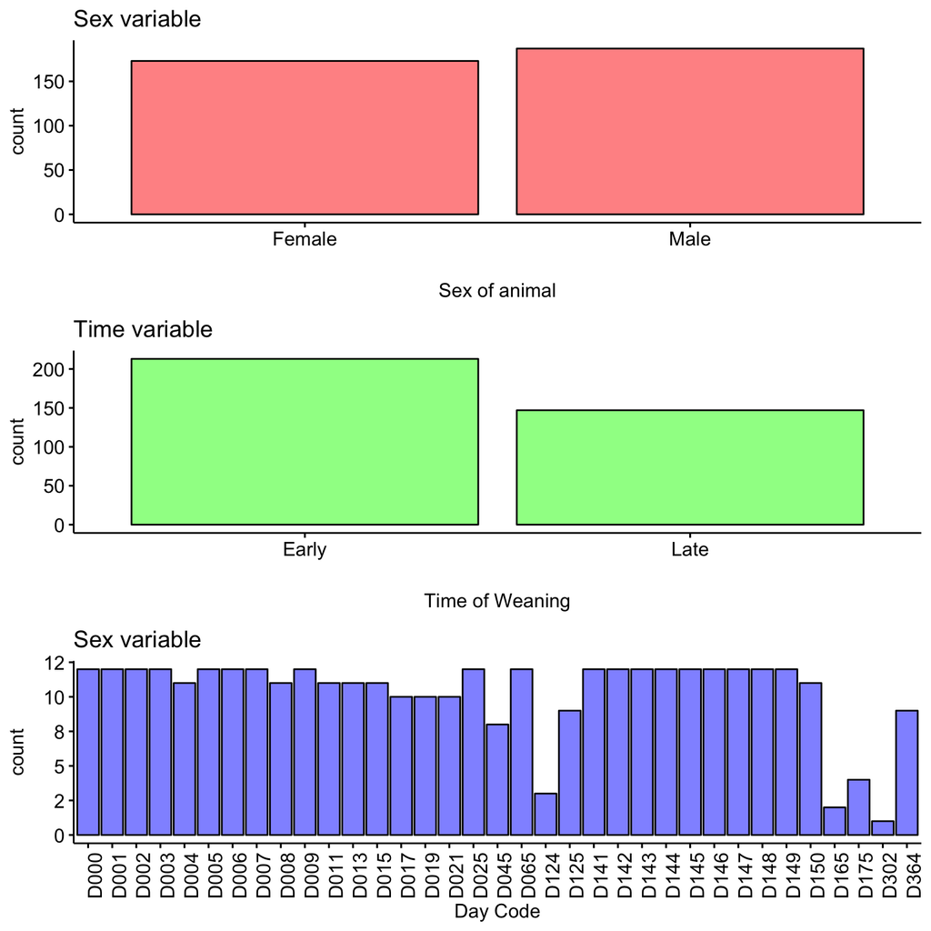

```r
library(ggplot2)
#sort by dpw (descending)

sexhistplot <- ggpubr::gghistogram(variables2, x = "Sex", stat="count", fill = "#ff0000") +
  labs(x = "Sex of animal", title = "Sex variable")

timehistplot <- ggpubr::gghistogram(variables2, x = "Time", stat="count", fill = "#00ff00") +
  labs(x = "Time of Weaning", title = "Time variable")

dpwhistplot <- ggpubr::gghistogram(variables2, x = "DayID", stat="count", fill = "#0000ff") +
  theme(axis.text.x=element_text(angle = 90, hjust = 0))+ scale_y_continuous(labels=scaleFUN) +
  labs(x = "Day Code", title = "Sex variable")

ggpubr::ggarrange(sexhistplot,timehistplot, dpwhistplot, ncol = 1, nrow = 3,  common.legend = TRUE, legend = "top", align = "hv", labels = c(""))
```

```r
save(samplemetadata, samplemetadata2, variables, variables2, file = "~/OneDrive/CaseStudy/iMAPpipeline_rev2/iMAPdemo/iMAP/code/Rmd/metadatavars.RData")
save(samplemetadata, samplemetadata2, variables, variables2, file = "~/GitHub/MAY2019/iMAP/code/Rmd/metadatavars.RData")
```

## Posible questions

### Metadata profiling

- QN1: Are there samples to be removed from the analysis based on their count?
- QN2: Are there enough variables for downstream diversity and statistical analysis?
- QN3: …….?
- QN4: …….?
- QN5: …….?

## Summary of packages used in the analysis